# Exploratory Short Paper

Andrew Yaspan

10/22/2017

## Project Introduction

The objective for this class is to conduct a thoughtful exploration of available data (in my case, public use files about the Affordable Care Act {ACA} Health Insurance Marketplace) and produce meaningful displays that impart useful insights. In order to make the most of detail of the data I have, I wanted to reduce the scope of the data I had available. Therefore, I am limiting myself to using data for the states surrounding Lake Michigan, Illinois, Wisconsin, Indiana, and Michigan.

While my main goal is to learn about and compare the health insurance plan offerings in these 4 states, I would also like to investigate the coverage of particular services. One set of services that relies heavily on the portion of the ACA that written to improve coverage and address complex public health issues is coverage of mental health and substance use services. Out of full transparency, I also wanted to include this plot to make a visual that could eventually contribute to my original project plan of focusing on local access to mental health and substance use treatment facilities:

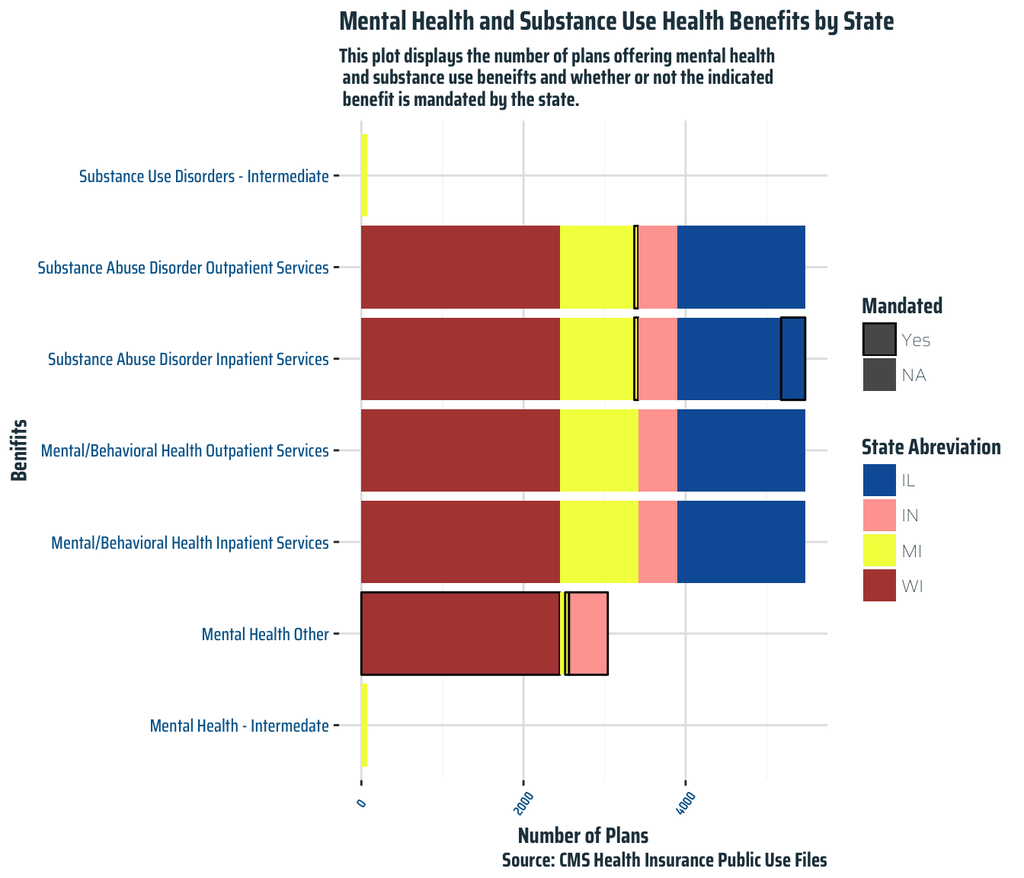

## Focus on Plan Comparison

To begin my concentration on comparing health insurance plan enrollment. This plot focuses specifically on the largest counties and plan enrollment from 2015 to 2016. I made several plots that included every county in each state, and then plots that focused on the mid-to-small sized counties of each state that demonstrated that there were several counties that reduced enrollment among many that gained enrollment. I included this plot of the largest counties in each state because I thought it demonstrates how large portions of each state’s population have behaved with fewer data points than show all the mid-to-small sized counties’ data points:

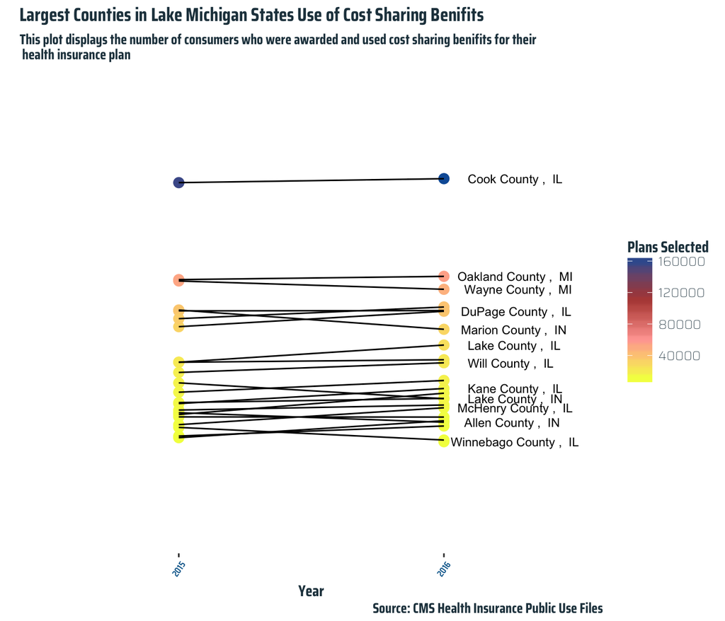

## A Cornerstone of the ACA, Cost Sharing

Next, I wanted to take a look at how many people of different income levels were purchasing health insurance in each state and receiving cost sharing benefits. This particular topic is highly relevant, since the president signed an executive order that would end payments to health insurance companies, which makes the cost sharing possible. Prior to this, Congress appealed to the Federal court system that the payments were unlawful. A federal court agreed with the claim, and now the case is pending a hearing with the D.C. Circuit Court of Appeals. As of now, payments for cost sharing will end in January. This is grounds for insurers to back out of contracts made with the federal government, which could lead to health insurance premium hikes making insurance unaffordable to millions of Americans.

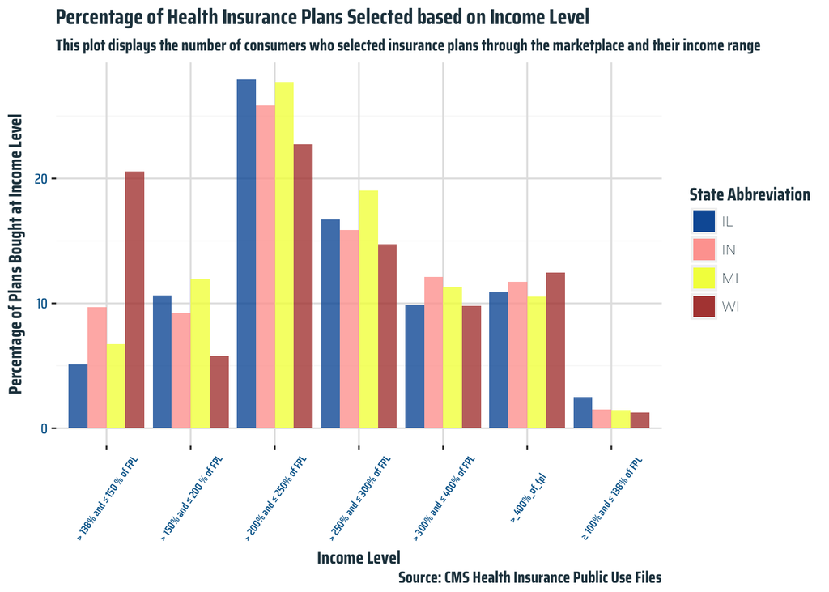

## Different Age, Different Price

A well known fact about health insurance is that health insurance companies are allowed to raise premiums for customers as they age. The curve in the following plots demonstrates nothing particularly exciting regarding that fact. What is interesting is how platinum plans are either not recorded to be available or are unavailable in Illinois and Indiana or are not offered at all. Another interesting insight is that premium increases are not exactly the same by state. Silver plans are significantly more expensive for older Americans in Wisconsin than the other three states.

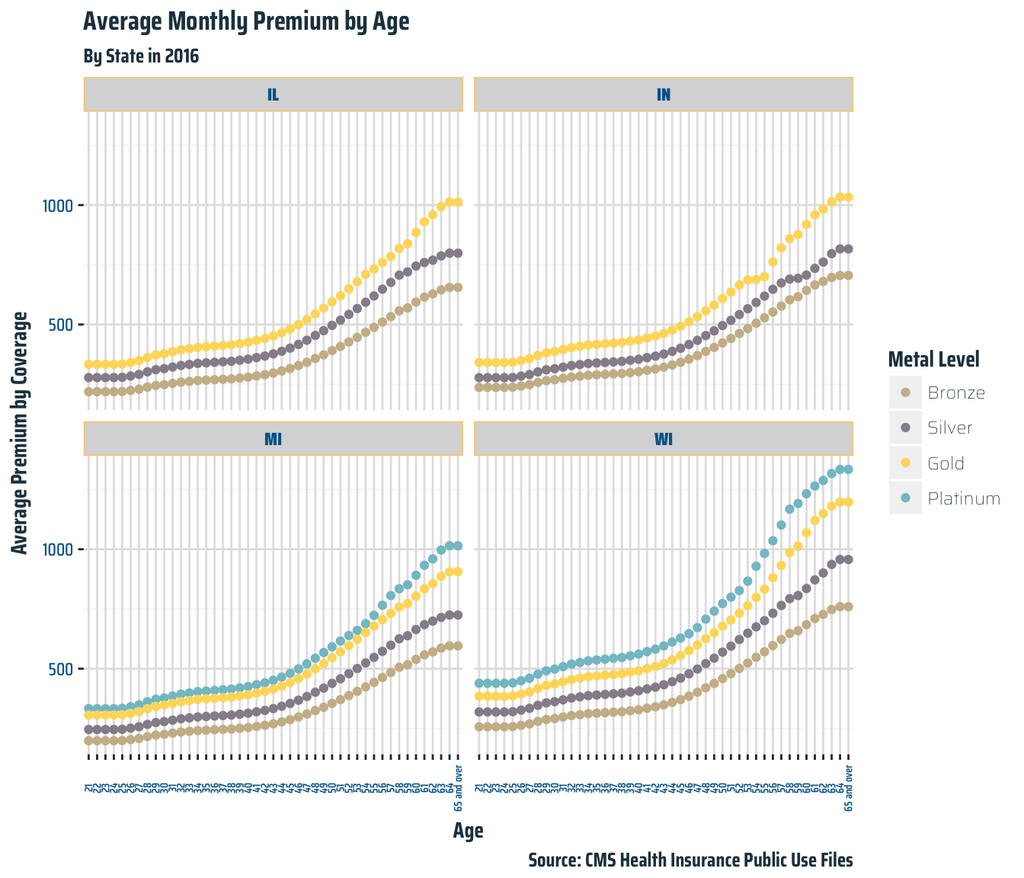

## Actuarial Values

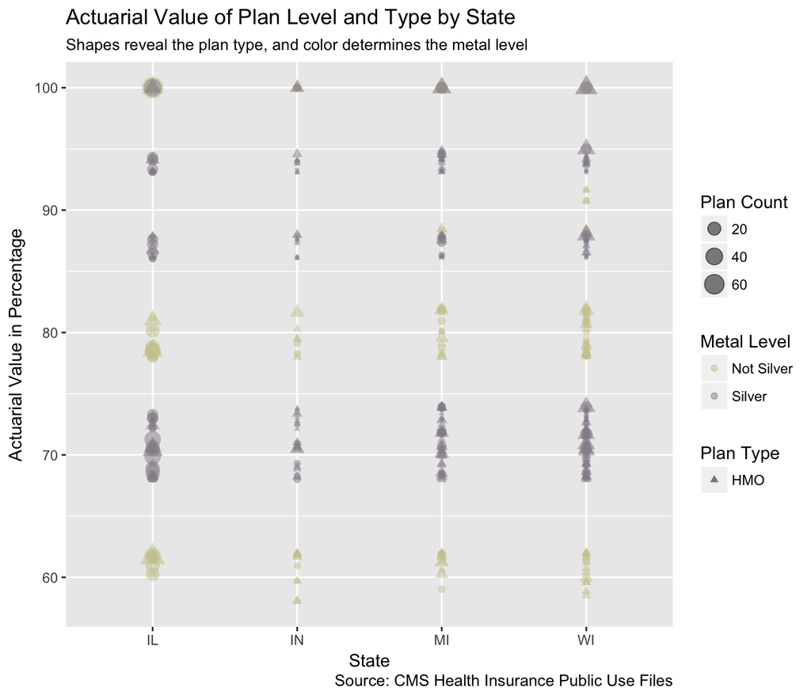

When we look closer at the composition of health insurance offerings in each state, it is interesting to see that most of the plans offered are these “middle-of-the-road” silver plans. Although silver plans certainly offer the best deal for many consumers who receive tax credits and cost sharing benefits, it surprising that they compose the largest share of ACA approved health insurance plans offered in these states, since without the subsidies they are more expensive than bronze plans. That being said, it encouraging to see that the policies that are most advantageous are offered in the greatest number.

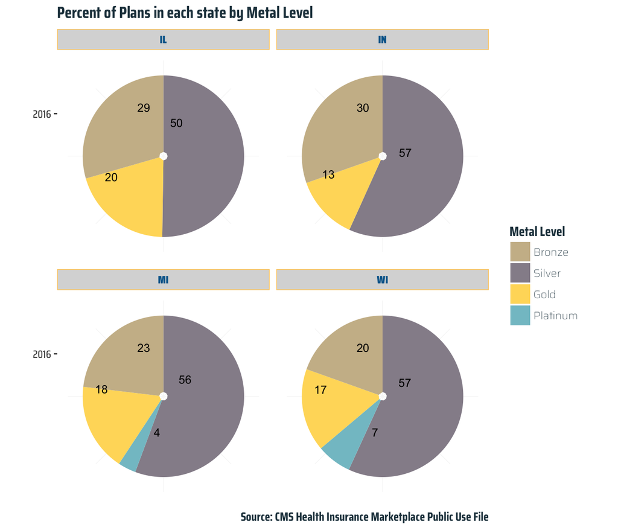

We can also dig into the proportion of marketplace purchased plans were bought with cost sharing benefits by county. Interestingly, Wisconsin seems to have the most counties with higher proportion of counties where the proportion of marketplace plans purchased with cost sharing was above 55%. At first glance, it seems that the greatest number of counties have between 25 and 50% plans purchased with cost sharing.

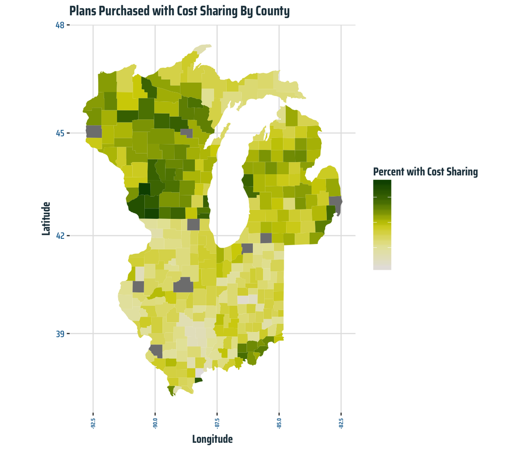

[output not shown]